# SAD - projekt 2

Mateusz Marciniewicz, Jakub Ficek

2021-06-09

# Zadanie 1

Korzystając z danych zamieszczonych na stronie http://bit.ly/covid19-poland

1. Sprawdź, czy proces szczepień przeciw SARS-CoV-2 przebiega równie szybko we wszystkich województwach, tzn. czy liczba szczepień jest proporcjonalna do populacji tych wojewdództw.
2. Sprawdź, czy skuteczność leczenia osób zarażonych wirusem SARS-CoV-2 jest taka sama na terenie całej Polski, tzn. czy liczba przypadków śmiertelnych jest proporcjonalna do liczby osób zarażonych w poszczególnych województwach.
3. W każdym z powyższych przypadków wskaż ewentualnie, które województwa istotnie się od siebie różnią pod kątem rozważanych statystyk.

Województwa: Warmińsko-mazurskie, Podlaskie, Łódzkie, Świętokrzyskie, Pomorskie, Lubuskie, Wielkopolskie

## Przygotowanie danych

```r
knitr::opts_chunk$set(echo = FALSE)

library(dplyr)
```

```r
library(tibble)
library(ggplot2)

regions <- c('warmińsko-mazurskie', 'podlaskie', 'łódzkie', 'świętokrzyskie', 'pomorskie', 'lubuskie', 'wielkopolskie')

population <- c(1422737, 1178353, 2454779, 1233961, 2343928, 1011592, 3498733)
vaccinations <- c(263721, 267059, 519258, 217296, 531317, 216534, 684786)
cases <- c(121787, 69806, 179791, 72909, 192160, 73969, 285208)
deaths <- c(2985, 2131, 5075, 2523, 4429, 2036, 7281)


covid_df <- data.frame(population, vaccinations, cases, deaths)
rownames(covid_df) <- regions

print(covid_df)
```

```
##                     population vaccinations  cases deaths
## warmińsko-mazurskie    1422737       263721 121787   2985
## podlaskie              1178353       267059  69806   2131
## łódzkie                2454779       519258 179791   5075
## świętokrzyskie         1233961       217296  72909   2523
## pomorskie              2343928       531317 192160   4429
## lubuskie               1011592       216534  73969   2036
## wielkopolskie          3498733       684786 285208   7281
```

## Sprawdzenie proporcjonalności szczepień (podpunkt a)

#### Założenie: za zaszczepione osoby uważamy te, które przyjęły już dwie dawki.

Zilustrujmy najpierw dane frakcje osób zaszczepionych (stosunek liczby zaszczepionych do populacji) w podziale na województwa.

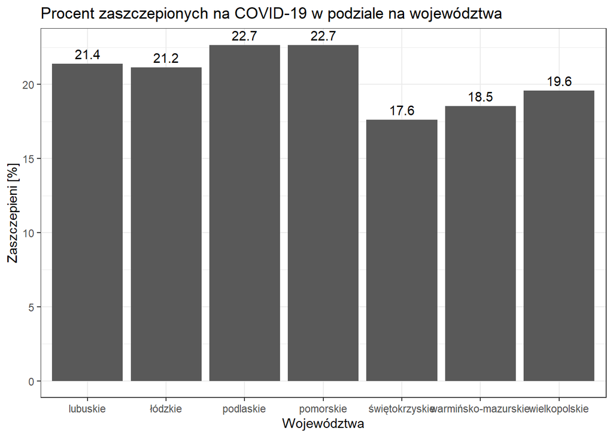

W celu sprawdzenia, czy proces szczepień przebiega równie szybko w każdym z rozważanych województw, możemy skorzystać z testu chi-kwadrat. Wyznaczenie wartości T określone jest wzorem:

$T = \sum^r_{i=1}\frac{(v_i-np_i)^2}{np_i}$

Będziemy zatem potrzebować następujących wartości:

- liczba zaszczepionych osób dla każdego z województw
- prawdopodobieństwo, obliczane jako iloraz populacji w danym województwie oraz populacji całkowitej

Pierwszy wektor wartości otrzymaliśmy ze zbioru danych. Drugi natomiast uzyskujemy za pomocą obliczenia:

```
##   population vaccinations  cases deaths probability_for_vaccinations
## 1    1422737       263721 121787   2985                   0.10824163
## 2    1178353       267059  69806   2131                   0.08964893
## 3    2454779       519258 179791   5075                   0.18675924
## 4    1233961       217296  72909   2523                   0.09387958
## 5    2343928       531317 192160   4429                   0.17832572
## 6    1011592       216534  73969   2036                   0.07696178
## 7    3498733       684786 285208   7281                   0.26618312
```

Przyjmijmy teraz pewne hipotezy:

$H_0$ = tempo szczepienia jest proporcjonalne do populacji

$H_1$ = tempo szczepienia nie jest propocjonalne do populacji

Test przeprowadzamy na poziomie istotności 0.05. Zależy nam zatem, aby szansa na otrzymany wynik (p-value) wynosiła co najmniej 0.95.

```
##
##  Chi-squared test for given probabilities
##
## data:  covid_df$vaccinations
## X-squared = 18106, df = 6, p-value < 2.2e-16
```

### Wnioski

Widzimy, że p-value jest bardzo małe, zdecydowanie dalekie od 95%. Możemy zatem odrzucić hipotezę zerową, jakoby proces szczepień odbywał się równomiernie we wszystkich województwach.

## Sprawdzenie równomiernego rozkładu śmierci (podpunkt b)

Zilustrujmy najpierw dane frakcje przypadków śmiertelnych (stosunek liczby śmierci z powodu koronawirusa do liczby potwierdzonych przypadków) w podziale na województwa.

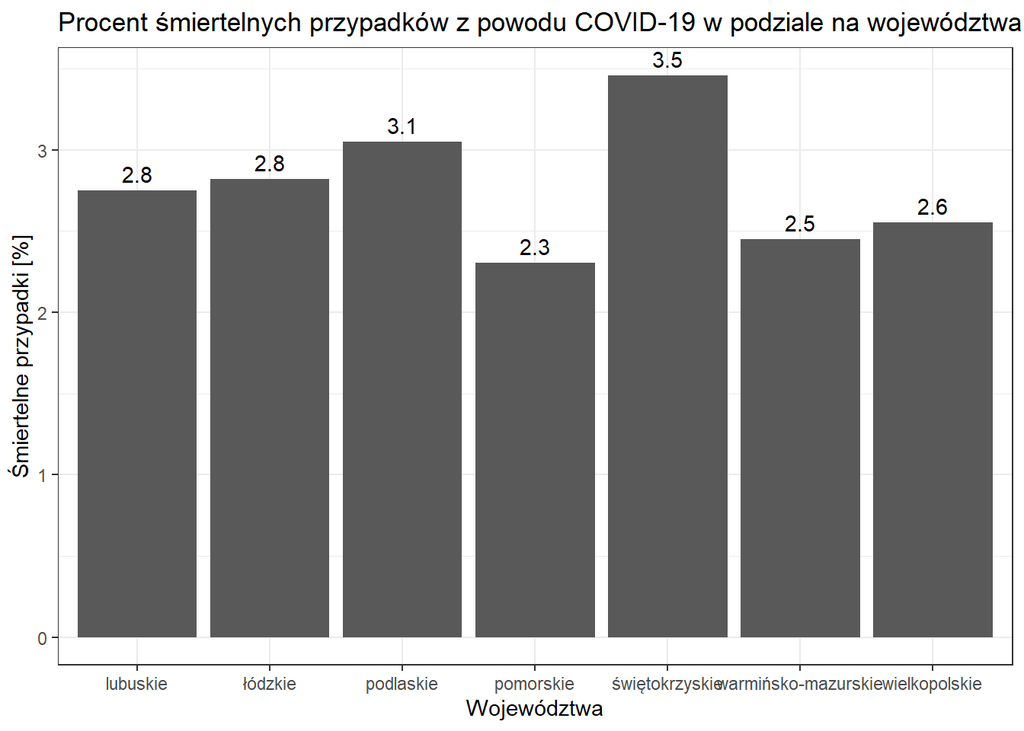

Do sprawdzenia możemy wykorzystać ten sam test, co w podpunkcie a) z tą różnicą, że zmienną testowaną będą śmierci, a prawdopodobieństwo obliczane będzie jako iloraz infekcji do sumy potwierdzonych przypadków zakażeń we wszystkich województwach.

```
##   population vaccinations  cases deaths probability_for_vaccinations
## 1    1422737       263721 121787   2985                   0.10824163
## 2    1178353       267059  69806   2131                   0.08964893
## 3    2454779       519258 179791   5075                   0.18675924
## 4    1233961       217296  72909   2523                   0.09387958
## 5    2343928       531317 192160   4429                   0.17832572
## 6    1011592       216534  73969   2036                   0.07696178
## 7    3498733       684786 285208   7281                   0.26618312
##   probability_for_deaths
## 1             0.12232155
## 2             0.07011239
## 3             0.18058014
## 4             0.07322901
## 5             0.19300342
## 6             0.07429366
## 7             0.28645983
```

Przyjmijmy teraz pewne hipotezy:

$H_0$ = rozkład śmierci jest proporcjonalny

$H_1$ = rozkład śmierci nie jest propocjonalny

Test przeprowadzamy na poziomie istotności 0.05. Zależy nam za czyli zależy nam zatem, aby szansa na otrzymany wynik (p-value) wynosiła co najmniej 0.95.

```
##
##  Chi-squared test for given probabilities
##
## data:  covid_df$deaths
## X-squared = 360.11, df = 6, p-value < 2.2e-16
```

### Wnioski

Znowu p-value jest zdecydowanie zbyt niska, a zatem hipoteza zerowa może zostać odrzucona.

## Badanie istotnych różnic pomiędzy województwami (podpunkt c)

```
##
##  Pairwise comparisons using Pairwise comparison of proportions
##
## data:  covid_df$vaccinations out of covid_df$population
##
##   1       2       3       4       5       6
## 2 < 2e-16 -       -       -       -       -
## 3 < 2e-16 < 2e-16 -       -       -       -
## 4 < 2e-16 < 2e-16 < 2e-16 -       -       -
## 5 < 2e-16 0.93    < 2e-16 < 2e-16 -       -
## 6 < 2e-16 < 2e-16 3.6e-07 < 2e-16 < 2e-16 -
## 7 < 2e-16 < 2e-16 < 2e-16 < 2e-16 < 2e-16 < 2e-16
##
## P value adjustment method: holm
```

```
##
##  Pairwise comparisons using Pairwise comparison of proportions
##
## data:  covid_df$deaths out of covid_df$cases
##
##   1       2       3       4       5       6
## 2 6.3e-14 -       -       -       -       -
## 3 6.3e-09 0.01081 -       -       -       -
## 4 < 2e-16 0.00012 3.2e-16 -       -       -
## 5 0.02671 < 2e-16 < 2e-16 < 2e-16 -       -
## 6 0.00032 0.00441 0.33667 8.2e-14 2.4e-10 -
## 7 0.11831 2.5e-12 2.7e-07 < 2e-16 5.3e-07 0.01081
##
## P value adjustment method: holm
```